# Project1_Penguins_Classification-and-decision-trees_E.Humbert

[ENG]

PROJECT 1 : PENGUINS - CLASSIFICATION AND DECISION TREES

[FR]

PROJET 1 : PINGOUINS - CLASSIFICATION ET ARBRES DE DECISION

```python
# Packages
import pandas as pd
import numpy as np

# Visualisation
import matplotlib.pyplot as plt
import seaborn as sns

# Machine Learning
from sklearn.tree import DecisionTreeClassifier, plot_tree
from sklearn.model_selection import train_test_split
from sklearn.metrics import accuracy_score
from sklearn.linear_model import LogisticRegression
from sklearn.inspection import DecisionBoundaryDisplay
```

```python
# Open penguins_iter csv file
penguins_iter= pd.read_csv("C:/Users/emmhu/OneDrive/Documents/E-LEARNING/DU DATA ANALYST/4_Introduction au ML supervisé/Données/Project_1_Penguins/penguins_lter.csv", sep=',')
penguins_iter.head()
```

|  | studyName | Sample Number | Species | Region | Island | Stage | Individual ID | Clutch Completion | Date Egg | Culmen Length (mm) | Culmen Depth (mm) | Flipper Length (mm) | Body Mass (g) | Sex | Delta 15 N (o/oo) | Delta 13 C (o/oo) | Comments |
| --- | --- | --- | --- | --- | --- | --- | --- | --- | --- | --- | --- | --- | --- | --- | --- | --- | --- |
| 0 | PAL0708 | 1 | Adelie Penguin (Pygoscelis adeliae) | Anvers | Torgersen | Adult, 1 Egg Stage | N1A1 | Yes | 11/11/07 | 39.1 | 18.7 | 181.0 | 3750.0 | MALE | NaN | NaN | Not enough blood for isotopes. |
| 1 | PAL0708 | 2 | Adelie Penguin (Pygoscelis adeliae) | Anvers | Torgersen | Adult, 1 Egg Stage | N1A2 | Yes | 11/11/07 | 39.5 | 17.4 | 186.0 | 3800.0 | FEMALE | 8.94956 | -24.69454 | NaN |
| 2 | PAL0708 | 3 | Adelie Penguin (Pygoscelis adeliae) | Anvers | Torgersen | Adult, 1 Egg Stage | N2A1 | Yes | 11/16/07 | 40.3 | 18.0 | 195.0 | 3250.0 | FEMALE | 8.36821 | -25.33302 | NaN |
| 3 | PAL0708 | 4 | Adelie Penguin (Pygoscelis adeliae) | Anvers | Torgersen | Adult, 1 Egg Stage | N2A2 | Yes | 11/16/07 | NaN | NaN | NaN | NaN | NaN | NaN | NaN | Adult not sampled. |
| 4 | PAL0708 | 5 | Adelie Penguin (Pygoscelis adeliae) | Anvers | Torgersen | Adult, 1 Egg Stage | N3A1 | Yes | 11/16/07 | 36.7 | 19.3 | 193.0 | 3450.0 | FEMALE | 8.76651 | -25.32426 | NaN |

```python
# Observing data structure
penguins_iter.shape
```

```
(344, 17)
```

```python
penguins_iter.info()
```

```
<class 'pandas.core.frame.DataFrame'>
RangeIndex: 344 entries, 0 to 343
Data columns (total 17 columns):
 #   Column               Non-Null Count  Dtype
---  ------               --------------  -----
 0   studyName            344 non-null    object
 1   Sample Number        344 non-null    int64
 2   Species              344 non-null    object
 3   Region               344 non-null    object
 4   Island               344 non-null    object
 5   Stage                344 non-null    object
 6   Individual ID        344 non-null    object
 7   Clutch Completion    344 non-null    object
 8   Date Egg             344 non-null    object
 9   Culmen Length (mm)   342 non-null    float64
 10  Culmen Depth (mm)    342 non-null    float64
 11  Flipper Length (mm)  342 non-null    float64
 12  Body Mass (g)        342 non-null    float64
 13  Sex                  334 non-null    object
 14  Delta 15 N (o/oo)    330 non-null    float64
 15  Delta 13 C (o/oo)    331 non-null    float64
 16  Comments             26 non-null     object
dtypes: float64(6), int64(1), object(10)
memory usage: 45.8+ KB
```

```python
penguins_iter.describe(include='all')
```

|  | studyName | Sample Number | Species | Region | Island | Stage | Individual ID | Clutch Completion | Date Egg | Culmen Length (mm) | Culmen Depth (mm) | Flipper Length (mm) | Body Mass (g) | Sex | Delta 15 N (o/oo) | Delta 13 C (o/oo) | Comments |
| --- | --- | --- | --- | --- | --- | --- | --- | --- | --- | --- | --- | --- | --- | --- | --- | --- | --- |
| count | 344 | 344.000000 | 344 | 344 | 344 | 344 | 344 | 344 | 344 | 342.000000 | 342.000000 | 342.000000 | 342.000000 | 334 | 330.000000 | 331.000000 | 26 |
| unique | 3 | NaN | 3 | 1 | 3 | 1 | 190 | 2 | 50 | NaN | NaN | NaN | NaN | 3 | NaN | NaN | 7 |
| top | PAL0910 | NaN | Adelie Penguin (Pygoscelis adeliae) | Anvers | Biscoe | Adult, 1 Egg Stage | N61A2 | Yes | 11/27/07 | NaN | NaN | NaN | NaN | MALE | NaN | NaN | Nest never observed with full clutch. |
| freq | 120 | NaN | 152 | 344 | 168 | 344 | 3 | 308 | 18 | NaN | NaN | NaN | NaN | 168 | NaN | NaN | 13 |
| mean | NaN | 63.151163 | NaN | NaN | NaN | NaN | NaN | NaN | NaN | 43.921930 | 17.151170 | 200.915205 | 4201.754386 | NaN | 8.733382 | -25.686292 | NaN |
| std | NaN | 40.430199 | NaN | NaN | NaN | NaN | NaN | NaN | NaN | 5.459584 | 1.974793 | 14.061714 | 801.954536 | NaN | 0.551770 | 0.793961 | NaN |
| min | NaN | 1.000000 | NaN | NaN | NaN | NaN | NaN | NaN | NaN | 32.100000 | 13.100000 | 172.000000 | 2700.000000 | NaN | 7.632200 | -27.018540 | NaN |
| 25% | NaN | 29.000000 | NaN | NaN | NaN | NaN | NaN | NaN | NaN | 39.225000 | 15.600000 | 190.000000 | 3550.000000 | NaN | 8.299890 | -26.320305 | NaN |
| 50% | NaN | 58.000000 | NaN | NaN | NaN | NaN | NaN | NaN | NaN | 44.450000 | 17.300000 | 197.000000 | 4050.000000 | NaN | 8.652405 | -25.833520 | NaN |
| 75% | NaN | 95.250000 | NaN | NaN | NaN | NaN | NaN | NaN | NaN | 48.500000 | 18.700000 | 213.000000 | 4750.000000 | NaN | 9.172123 | -25.062050 | NaN |
| max | NaN | 152.000000 | NaN | NaN | NaN | NaN | NaN | NaN | NaN | 59.600000 | 21.500000 | 231.000000 | 6300.000000 | NaN | 10.025440 | -23.787670 | NaN |

```python
#Counting missing values and calculating proportion
missing_value= penguins_iter.isnull().sum()
print(missing_value)

missing_value_proportion = ((missing_value * 100) / len(penguins_iter)).round(2)
print("\nMissing values proportion (%):\n", missing_value_proportion)
```

```
studyName                0
Sample Number            0
Species                  0
Region                   0
Island                   0
Stage                    0
Individual ID            0
Clutch Completion        0
Date Egg                 0
Culmen Length (mm)       2
Culmen Depth (mm)        2
Flipper Length (mm)      2
Body Mass (g)            2
Sex                     10
Delta 15 N (o/oo)       14
Delta 13 C (o/oo)       13
Comments               318
dtype: int64

Missing values proportion (%):
 studyName               0.00
Sample Number           0.00
Species                 0.00
Region                  0.00
Island                  0.00
Stage                   0.00
Individual ID           0.00
Clutch Completion       0.00
Date Egg                0.00
Culmen Length (mm)      0.58
Culmen Depth (mm)       0.58
Flipper Length (mm)     0.58
Body Mass (g)           0.58
Sex                     2.91
Delta 15 N (o/oo)       4.07
Delta 13 C (o/oo)       3.78
Comments               92.44
dtype: float64
```

```python
# Fill missing values in Culmen Length (mm), Culmen Depth (mm), Flipper Length (mm), Body Mass (g)
penguins_iter['Culmen Length (mm)'].fillna(penguins_iter['Culmen Length (mm)'].mean(), inplace=True)
penguins_iter['Culmen Depth (mm)'].fillna(penguins_iter['Culmen Depth (mm)'].mean(), inplace=True)
penguins_iter['Flipper Length (mm)'].fillna(penguins_iter['Flipper Length (mm)'].mean(), inplace=True)
penguins_iter['Body Mass (g)'].fillna(penguins_iter['Body Mass (g)'].mean(), inplace=True)
```

[ENG]

1. Train a depth tree 1. You can use DecisionTreeClassifier from sklearn.tree, on Python.

[FR]

1. Entrainez un arbre de profondeur 1. Vous pouvez utiliser DecisionTreeClassifier depuis sklearn.tree, sur Python.

```python
# Select relevant columns and separate features (X) and target (y)
penguins_cleaned = penguins_iter[['Culmen Length (mm)', 'Culmen Depth (mm)', 'Species']]
X = penguins_cleaned[['Culmen Length (mm)', 'Culmen Depth (mm)']]
y = penguins_cleaned['Species']

# Define species classes for use in plot
species= ['Species']
```

```python
# Split the dataset into 80 % train, 20% test
X_train, X_test, y_train, y_test = train_test_split(X,y, test_size= 0.2, stratify= y, random_state=1)
```

```python
# Instantiate de DecisionTreeClassifier 'dt' with a maximum depth of 1
dt= DecisionTreeClassifier(max_depth= 1, random_state= 1)
```

```python
# Fit dt to the training set
dt.fit(X_train, y_train)
```

```
DecisionTreeClassifier(max_depth=1, random_state=1)
```

```python
# Predict the test set labels
y_pred= dt.predict(X_test)
```

```python
# Evaluate the test-set accuracy
accuracy= accuracy_score(y_test, y_pred)
print("Test set accuracy: {:.2f}".format(accuracy))
```

```
Test set accuracy: 0.75
```

[ENG]

2. You will then produce a scatterplot centred on the culmen, with its length on the X axis and its depth on the Y axis. The various individuals in the dataset will be displayed on the plane thus created, so that the colour of the point differs according to the species. A classic scatterplot (from Seaborn, for example) is required.

[FR]

2. Vous allez ensuite produire un scatterplot centré sur le culmen, avec pour l’axe X sa longueur, et pour l’axe Y sa profondeur. Les différents individus du jeu de données vont être affichés sur le plan ainsi créé, de sorte que la couleur du point diffère selon l’espèce. Un scatterplot classique (de seaborn par exemple) est requis.

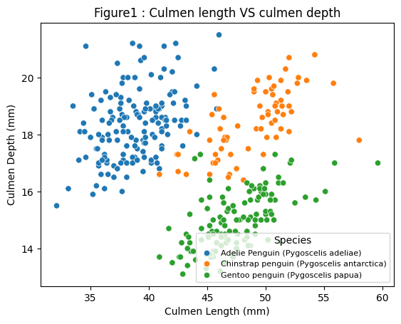

```python
# Create a scatterplot centered on culmen using seaborn
sns.scatterplot(data=penguins_cleaned,x= 'Culmen Length (mm)',y= 'Culmen Depth (mm)', hue= 'Species')
plt.title("Figure1 : Culmen length VS culmen depth")

# Customize the legend
plt.legend(title= "Species", loc= "lower right", fontsize='8')

plt.savefig("Figure1_culmen_length_vs_culmen_depth.png", dpi=300, bbox_inches='tight')

plt.show()
```

### Figure 1: Relationship Between Culmen Length and Culmen Depth in Penguin Species

This figure illustrates the relationship between **culmen length** and **culmen depth** across three penguin species: *Adelie* (blue), *Chinstrap* (orange), and *Gentoo* (green). Each point represents an individual penguin.

This distinct clustering indicates that **culmen measurements are effective morphological traits** for distinguishing between species. The plot is valuable for visualizing natural groupings in biological datasets and supports species classification through quantitative features.

[ENG]

3. Show the scatterplot in the partition made by the tree. The expected result is shown in Figure 2. In scikitlearn, the function (DecisionBoundaryDisplay.from estimator) will be used. It must be called before making the scatterplot. Which variable did the tree used to partition the dataset?

[FR]

3. Faites apparaître le scatterplot dans la partition faite par l’arbre. Le résultat attendu est en Figure 2. Dans scikitlearn, la fonction (DecisionBoundaryDisplay.from estimator) sera utilisée. Il est nécessaire de l’appeler avant de faire le scatterplot. Quelle variable l’arbre de classification a-t-il utilisé pour partitionner le jeu de données ?

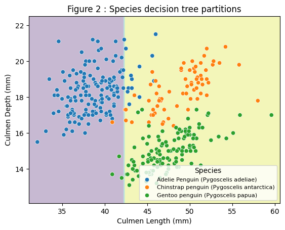

```python
# Plot decision boundaries
DecisionBoundaryDisplay.from_estimator(dt, X, response_method="predict", alpha=0.3)

# Scatterplot centered on culmen
sns.scatterplot(data=penguins_cleaned, x='Culmen Length (mm)', y='Culmen Depth (mm)', hue='Species')

# Customize the legend and labels
plt.legend(title="Species", loc="lower right", fontsize='8')
plt.xlabel('Culmen Length (mm)')
plt.ylabel('Culmen Depth (mm)')
plt.title('Figure 2 : Species decision tree partitions')

plt.savefig("Figure2_species_decision_tree_partitions.png", dpi=300, bbox_inches='tight')

plt.show()
```

### Figure 2: Species classification partitions using a decision tree

This figure presents the classification boundaries generated by a **decision tree classifier** trained on penguin morphological features: **culmen length** and **culmen depth**. Each point represents an individual penguin, colored by species: *Adelie*, *Chinstrap*, and *Gentoo*.

This visualization clearly shows how the decision tree splits the feature space primarily based on **culmen length**, resulting in vertical decision boundaries. Such partitioning aligns with the tree’s logic of performing axis-aligned splits, which can be **interpretable but may oversimplify boundaries** when features are not well separated.

Overall, this plot demonstrates how decision trees classify species based on key morphological traits and offers insight into the **model's behavior and potential misclassification zones**.

[ENG]

4. Display the corresponding classification tree (plot tree function in sklearn-tree), as in Figure 3 (where we have removed some information). What do you notice about the choice of label for each leaf of the tree? Is it consistent with the numerical values displayed? How do you think this model would behave if it were used according to a predictive logic? What type of penguin would be ignored ?

[FR]

4. Faites apparaître l’arbre de classification correspondant (fonction plot tree de sklearn-tree), comme dans la Figure 3 (où nous avons enlevé des informations). Que constatez-vous quant au choix du label retenu pour chacune des feuilles de l’arbre ? Est-il cohérent avec les valeurs numériques affichées ? Dès lors, comment pensez-vous que se comporterait ce modèle s’il était utilisé selon une logique de prédiction ? Quel type de pingouin serait ignoré ?

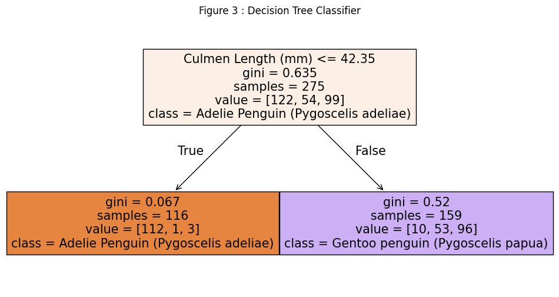

```python
# Plot the decision tree
plt.figure(figsize=(12, 6))


plot_tree(dt, max_depth= 1, feature_names= ['Culmen Length (mm)', 'Culmen Depth (mm)'], class_names=dt.classes_, label='all',filled=True, impurity=True,
          node_ids=False, proportion=False, rounded=False, precision=3, ax=None, fontsize=None)
plt.title('Figure 3 : Decision Tree Classifier')

plt.savefig("Figure3_decision_tree_classifier.png", dpi=300, bbox_inches='tight')

plt.show()
```

### Figure 3 : Commentary on the decision tree model

#### 1. Root and leaf labels

Investigating the leaves, we observe that only **Adelie** and **Gentoo** penguins are explicitly represented.  
**Chinstrap penguins**, while present in the data, do not appear distinctly in the tree structure.  
This suggests that Chinstrap samples are absorbed into other classes without clear separation.

The distribution is coherent in terms of sample counts:  
the total value at the root node is divided between the two leaves.

#### 2. Model behavior and potential underfitting

As a result:

- The model fails to create distinct paths for all penguin species.
- **Chinstrap penguins are not well isolated** and likely get classified as either Adelie or Gentoo, depending on their measurements.
- This indicates that the model is **underfitting** the data, unable to capture the complexity needed to distinguish all species.

#### 3. Practical implications

In a real-world prediction scenario, this model would **not be effective** for correctly identifying all penguin types.  
Without deeper splits or additional distinguishing features, Chinstrap penguins are at a high risk of being **misclassified or ignored**.

To improve the model:

- **Increase the tree depth** to allow more complex decision boundaries.
- **Incorporate additional features** that better differentiate Chinstrap penguins from the other species.

#### Key insights

The model, with its shallow structure, underfits the data and overlooks Chinstrap penguins.  
For better performance, the tree needs deeper splits and potentially richer feature information to achieve finer-grained classification.

[ENG]

5. Take a sample where the length is 35 mm, and the depth is 17 mm (this is not an existing sample, but a new example, you have to create it from scratch). Make a prediction as to which class of penguin the beak belongs to (tree.predict proba in Python). The result should look like Figure 4. How do you interpret your results? Establish a link between the probabilities obtained and some of the numerical values in the leaves of the tree.

[FR]

5. Prenez un échantillon où la longueur est de 35 mm, et la profondeur de 17 mm (ce n’est pas un échantillon existant, mais un nouvel example, vous devez le créer de toute pièce). Réalisez une prédiction quant a la classe de pingouin a laquelle le bec appartient (tree.predict proba en Python). Le résultat recherché doit ressembler a la Figure 4. Comment interprétez vous vos résultats ? Etablissez un lien entre les probabilités obtenues et certaines des valeurs chiffrées présentes dans les feuilles de l’arbre.

```python
# Create a new sample with 35mm length and 17mm depth
new_beak= np.array([[35, 17]])
```

```python
# Split the dataset into 80 % train, 20% test
X_train, X_test, y_train, y_test = train_test_split(X,y, test_size= 0.2, stratify= y, random_state=2)
```

```python
# Train the decision tree classifier
dt2 = DecisionTreeClassifier(max_depth=1, random_state=2)
dt2.fit(X_train, y_train)
```

```
DecisionTreeClassifier(max_depth=1, random_state=2)
```

```python
# Predict probabilities for each penguin class
class_probabilities1 = dt2.predict_proba(new_beak)[0]

# Display the probabilities for interpretation
print("Predicted probabilities for each penguin class:", class_probabilities1)
```

```
Predicted probabilities for each penguin class: [0.96521739 0.00869565 0.02608696]
```

```python
# Assuming `class_labels` contains the names of the classes (species)
class_labels1= dt2.classes_
```

```python
# Display penguins classes
print("Classes de pingouins :", dt2.classes_)
```

```
Classes de pingouins : ['Adelie Penguin (Pygoscelis adeliae)'
 'Chinstrap penguin (Pygoscelis antarctica)'
 'Gentoo penguin (Pygoscelis papua)']
```

```python
# Display the predicted probabilities
print("Predicted probabilities for the new sample:")
for label, prob in zip(class_labels1, class_probabilities1):
    print(f"{label}: {prob:.3f}")
```

```
Predicted probabilities for the new sample:
Adelie Penguin (Pygoscelis adeliae): 0.965
Chinstrap penguin (Pygoscelis antarctica): 0.009
Gentoo penguin (Pygoscelis papua): 0.026
```

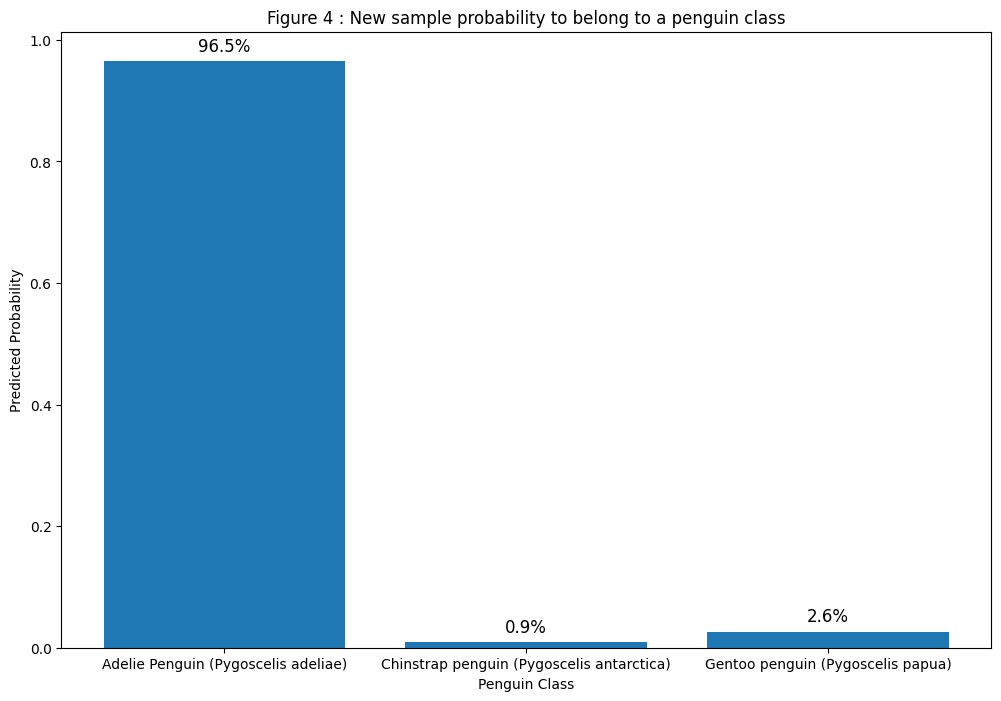

```python
# Create a barplot
plt.figure(figsize=(12,8))

plt.bar(class_labels1,class_probabilities1)

plt.xlabel("Penguin Class")
plt.ylabel("Predicted Probability")
plt.title("Figure 4 : New sample probability to belong to a penguin class")
plt.xticks(ticks=class_labels1, labels=class_labels1)

for i,prob in enumerate(class_probabilities1):
    plt.text(i, prob + 0.01, f"{prob * 100:.1f}%", ha='center', va='bottom', fontsize=12)

plt.savefig('Figure4_new_sample_probability.png', dpi=300, bbox_inches='tight')

plt.show()
```

### Figure 4 : New sample probability to belong to a penguin class

If this new sample existed, the predicted probabilities of belonging to each penguin class would be:

- **96.5%** for Adelie Penguins,
- **0.9%** for Chinstrap Penguins,
- **2.6%** for Gentoo Penguins.

#### Explanation based on the decision tree

The **high probability for the Adelie Penguin** can be explained by the structure of the previously created decision tree:

#### Behavior within the leaf nodes

Once the sample reaches a leaf:

- Only the **Gini impurity** value remains to guide the prediction.
- Since the culmen length is under 42.35 mm, culmen length is **no longer used** at this point.
- Observations:
  - One leaf has a **Gini value of 0.067**, indicating low impurity (almost pure).
  - The other leaf has a **Gini value of 0.52**, indicating higher impurity.

**Note:**  
A Gini impurity of **0.067** still reflects a certain level of disorder, but not maximum — maximum impurity for binary classification is **0.5** (not 0.067).  
A pure leaf (containing only one class) would have a Gini impurity of **0**.

#### How to improve the model

Adding **more depth** to the decision tree would likely:

- Allow the model to create more **specific splits**.
- **Improve classification probabilities** for Chinstrap and Gentoo penguins.
- Potentially **reduce** the overwhelming bias toward Adelie Penguins.

Increasing depth would help the model better **capture the nuances** between the species based on culmen measurements and other features.

[ENG]

6. Repeat all the steps presented here, but with a maximum tree depth of 2. Produce the corresponding graph.

[FR]

6. Répétez l’ensemble des étapes présentées ici, mais avec une profondeur de 2 d’arbre maximale de 2. Produisez les graphiques correspondants.

```python
new_beak= np.array([[35, 17]])
```

```python
# Split the dataset into 80 % train, 20% test
X_train, X_test, y_train, y_test = train_test_split(X,y, test_size= 0.2, stratify= y, random_state=3)
```

```python
# Train the decision tree classifier
dt3 = DecisionTreeClassifier(max_depth=2, random_state=3)
dt3.fit(X_train, y_train)
```

```
DecisionTreeClassifier(max_depth=2, random_state=3)
```

```python
# Predict probabilities for each penguin class
class_probabilities2= dt3.predict_proba(new_beak)[0]

# Display penguins classes
print("Classes de pingouins :", dt3.classes_)
```

```
Classes de pingouins : ['Adelie Penguin (Pygoscelis adeliae)'
 'Chinstrap penguin (Pygoscelis antarctica)'
 'Gentoo penguin (Pygoscelis papua)']
```

```python
# Retrieve class labels
class_labels2= dt3.classes_
```

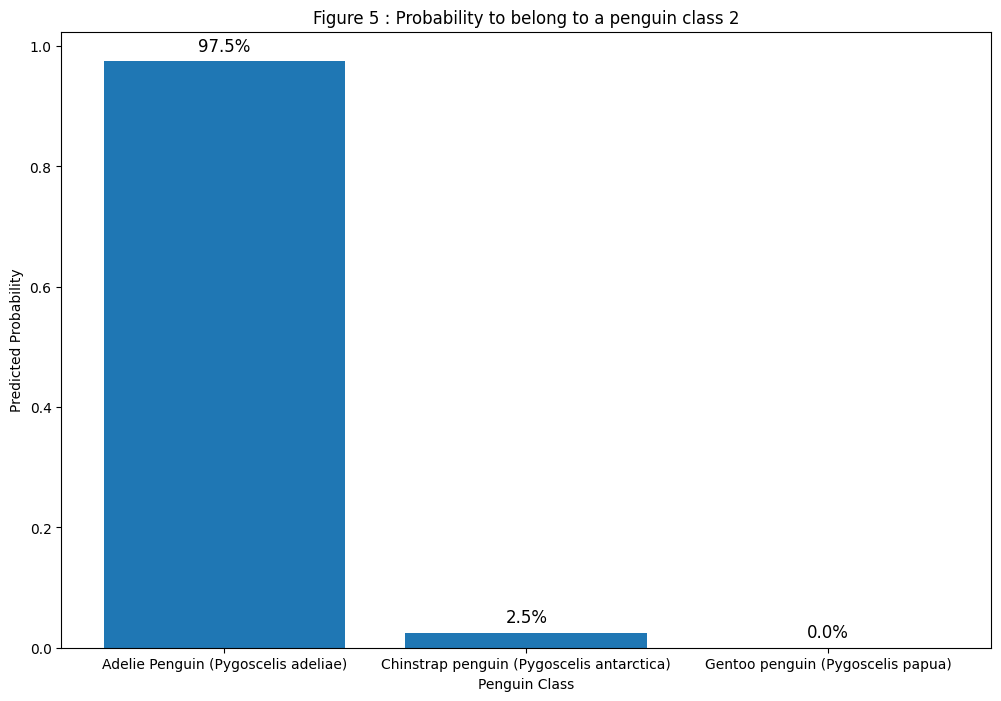

```python
# Create a bar plot
plt.figure(figsize=(12,8))

plt.bar(class_labels2,class_probabilities2)

plt.title('Figure 5 : Probability to belong to a penguin class 2')
plt.xlabel('Penguin Class')
plt.ylabel('Predicted Probability')
plt.xticks(ticks=class_labels2, labels=class_labels2)

for i, prob in enumerate(class_probabilities2):
    plt.text(i, prob+0.01,f"{prob * 100:.1f}%", ha='center', va='bottom', fontsize=12)

plt.savefig('Figure5_new_sample_probability_2.png', dpi=300, bbox_inches='tight')

plt.show()
```

#### Effect of increasing max_depth to 2

By increasing the **max_depth** of the decision tree to **2** and creating a new sample, we observe a slightly different result:

- **Chinstrap Penguins** become more visible, with a predicted probability of **2.5%**.
- **Adelie Penguins** still dominate, with a very high predicted probability of **97.5%**.
- **Gentoo Penguins** now have **0%** probability, meaning they are no longer selected by the model for this new sample.

#### Interpretation

Adding an additional depth level allowed the model to create more refined splits,  
which helps slightly differentiate Chinstrap Penguins from the other classes.

However, the classification remains heavily biased toward Adelie Penguins, suggesting that:

- **More features** or **deeper trees** might be necessary to achieve a better separation among all three species.
- The current model is still not perfectly capable of identifying Gentoo Penguins for this particular sample.